# Conversion to 3NF | Coursera

# Third normal form dependency diagrams

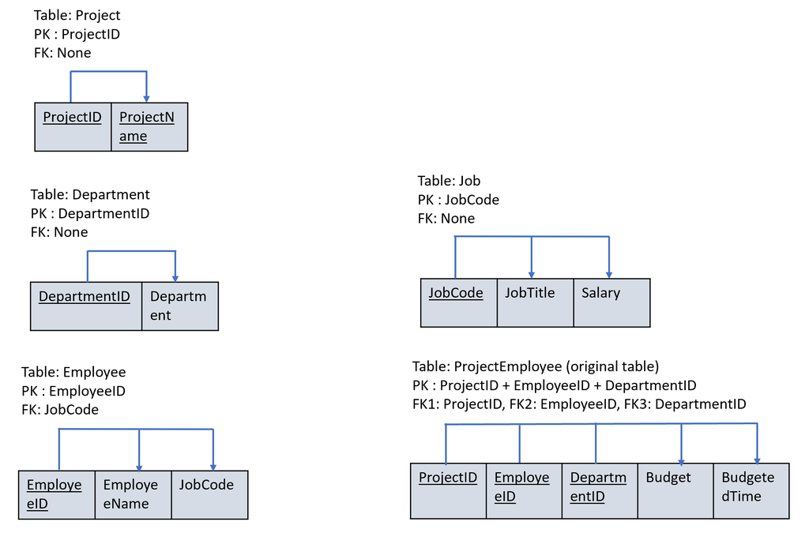

### Third normal form relation schemas

**table1:** Project (ProjectID, ProjectName)

**table2:** Employee (EmployeeID, EmployeeName, JobCode)

**table3:** Department (DepartmentID, DepartmentName)

**table4:** ProjectEmployee (ProjectID, EmployeeID, DepartmentID, Budget, BudgetedTime)

**table5:** Job (JobCode, JobTitle, Salary)

# Third normal form tables with data values

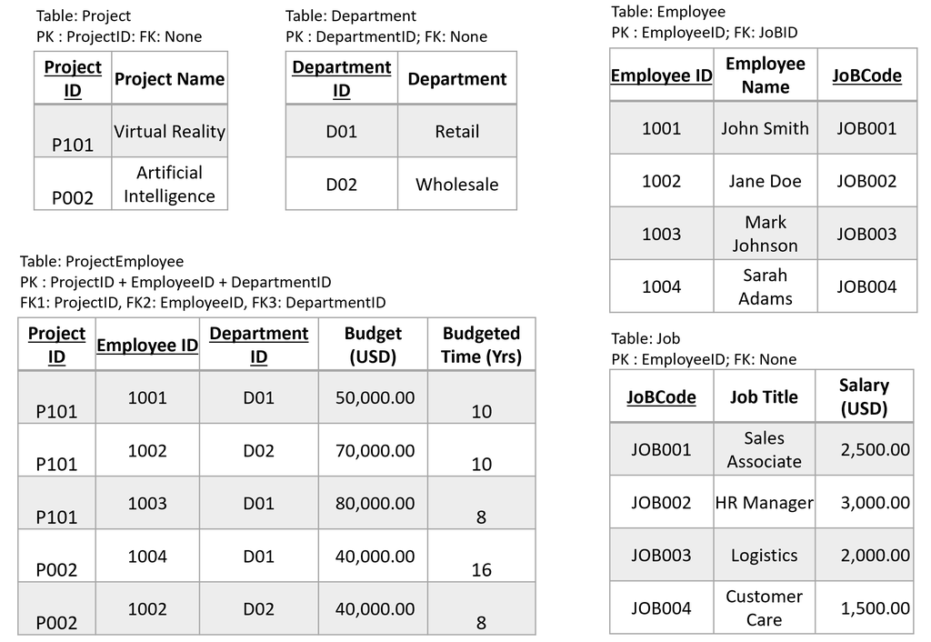

The tables above satisfy the third normal form requirements:

- Each table is in 2NF.
- None of the tables include transitive dependencies.